# Welcome to the dev-version of the

# [library flip on CRAN](http://cran.r-project.org/web/packages/flip/index.html)

## Set up

To **install** this github version type (in R):

```
#if devtools is not installed yet:
# install.packages("devtools")
library(devtools)
install_github("livioivil/flip")
```

## Some examples

```r
library(flip)
```

*A univariate analysis*

Testing the symmetry around 0 in a one sample (i.e. equivalent to one sample t-test)

```r
set.seed(1)
y=rnorm(10)+.5
res=flip(y)
summary(res)
```

```
##  Call:
##  flip(Y = y)
## 1023 permutations.
##   Test  Stat tail p-value sig.
## Y    t 2.561   ><  0.0293    *
```

and ploting

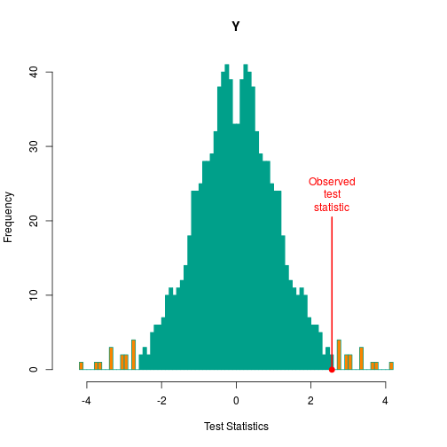

```r
plot(res) # same ad hist(res)
```

*A multivarite analysis*

```r
set.seed(1)
df=data.frame(y1=rnorm(10)+.5,y2=rnorm(10))
res=flip(~.,data=df)
summary(res)
```

```
##  Call:
##  flip(Y = ~., data = df)
## 1023 permutations.
##    Test   Stat tail p-value sig.
## y1    t 2.5612   ><  0.0293    *
## y2    t 0.7358   ><  0.4844
```

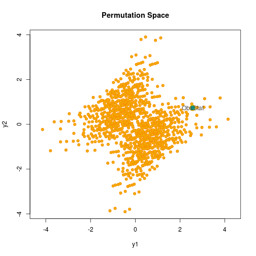

```r
plot(res)
```

Which is different from ploting

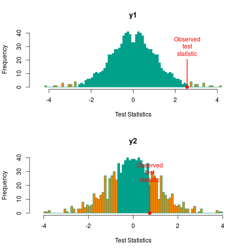

```r
##set the following if you get an error (mostly using Rstudio)
#par(mar=c(1,1,1,1))
hist(res)
```

## References

For the general framework of univariate and multivariate permutation tests see:

*Pesarin, F. (2001) Multivariate Permutation Tests with Applications in Biostatistics. Wiley, New York.*

For analysis of mixed-models see:

*L. Finos and D. Basso (2014) Permutation Tests for Between-Unit Fixed Effectsin Multivariate Generalized Linear Mixed Models. Statistics and Computing. Volume 24, Issue 6, pp 941-952. DOI: 10.1007/s11222-013-9412-6*

*D. Basso, L. Finos (2011) Exact Multivariate Permutation Tests for Fixed Effects in Mixed-Models. Communications in Statistics - Theory and Methods. DOI 10.1080/03610926.2011.627103*

For Rotation tests see:

*Langsrud, O. (2005) Rotation tests, Statistics and Computing, 15, 1, 53-60*

*A. Solari, L. Finos, J.J. Goeman (2014) Rotation-based multiple testing in the multivariate linear model. Biometrics. Accepted*

The colors of the plots of library flip are mostly taken from `display.wes.palette(5, "Darjeeling")` of [library(wesanderson)](https://github.com/karthik/wesanderson).